# Introduction to shiny apps

## What is shiny

- Package from RStudio (http://shiny.rstudio.com/)
- Interactive analysis of data
- Stand-alone applications and dashboards

```r
if (!require("devtools"))
  install.packages("devtools")
devtools::install_github("rstudio/shiny")
```

## Components of an application

- Two files
  1. User-Interface file (ui.R) - inputs and display of output in a customizable layout
  2. Server (server.R) - the work-horse that takes inputs, processes them, and creates outputs to display in the user-interface
- One-file option exists using shiny markdown… My preference is for two separate files.

## Developing a sample application using iris

Sepal length and width and Petal length and width of 50 flowers from each of 3 species of iris - setosa, versicolor, and virginica

1. View data (or a part of it)
2. Summarize data
3. 2 graphs of data - a scatter plot and a box plot

## View Data

```r
head(iris,5)
```

```
##   Sepal.Length Sepal.Width Petal.Length Petal.Width Species
## 1          5.1         3.5          1.4         0.2  setosa
## 2          4.9         3.0          1.4         0.2  setosa
## 3          4.7         3.2          1.3         0.2  setosa
## 4          4.6         3.1          1.5         0.2  setosa
## 5          5.0         3.6          1.4         0.2  setosa
```

```r
# tail(iris,n)
# iris
```

## Summarize Data

```r
summary(iris)
```

```
##   Sepal.Length    Sepal.Width     Petal.Length    Petal.Width
##  Min.   :4.300   Min.   :2.000   Min.   :1.000   Min.   :0.100
##  1st Qu.:5.100   1st Qu.:2.800   1st Qu.:1.600   1st Qu.:0.300
##  Median :5.800   Median :3.000   Median :4.350   Median :1.300
##  Mean   :5.843   Mean   :3.057   Mean   :3.758   Mean   :1.199
##  3rd Qu.:6.400   3rd Qu.:3.300   3rd Qu.:5.100   3rd Qu.:1.800
##  Max.   :7.900   Max.   :4.400   Max.   :6.900   Max.   :2.500
##        Species
##  setosa    :50
##  versicolor:50
##  virginica :50
##
##
##
```

## Plot 1 - Scatter plot

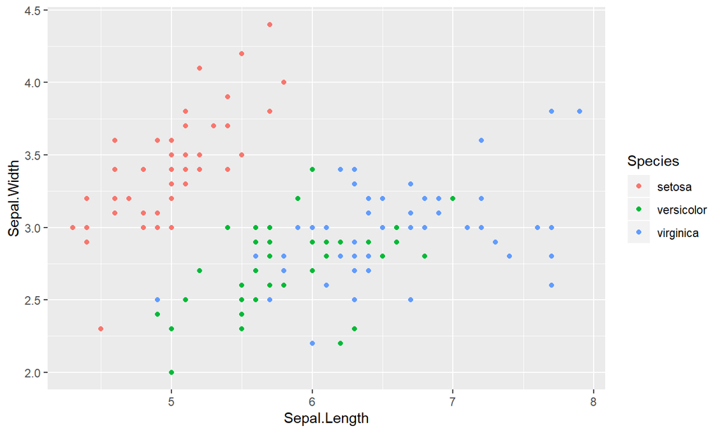

```r
library(ggplot2)
ggplot(iris,aes(x=Sepal.Length,y=Sepal.Width,color=Species))+geom_point()
```

## Plot 2 - Box plot

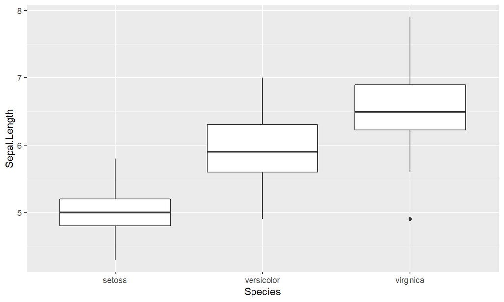

```r
ggplot(iris,aes(x=Species,y=Sepal.Length))+geom_boxplot()
```

## Recap

1. View data (or a section of it) (using `head`, `tail`, or just the entire data)
2. Summarize data (using `summary`)
3. 2 graphs of data - a scatter plot (x= Sepal.Length, y= Sepal.Width) and a box plot (how distribution of Sepal.Length varied across the three Species)

## Imagine the difficulty below

1. What if one wanted the ability to specify any variable for x and y axes of the scatter plot?
2. What if one wanted to alter the variable whose distribution one wanted to plot across the three species in the box plot?
3. What if one wanted to select a subset of the data (any range of any of the 4 numeric variables) and wanted to see how the data, summary, and the two plots changed?

## Let’s work on the user interface

Off-the-shelf widgets for inputs: http://shiny.rstudio.com/gallery/widget-gallery.html

[interactive chart not shown]

## Our Widgets

- One “Select box” each for the x-variable and y-variable (for scatter plot), and one “Select box” for the dvariable (for distribution to study in box plot) - The options for each of the 3 select boxes will be the same, the four numeric variables
- One “Slider range” for each of the four numeric variables - the minimum and maximum for each “Slider range” should be the minimum and maximum of the variable they are representing. Default state of each: The entire range (complete dataset)

## Input widgets for user interface

```r
# The 5th variable in the iris dataset is not numeric - Species - Not a choice option
selectInput("xvar", "x-variable:", choices=names(iris[,-5]))
selectInput("yvar", "y-variable:", choices=names(iris[,-5]),selected = names(iris[2]))
selectInput("dvar", "Distribution of which variable for box plot?", choices=names(iris[,-5]), selected = names(iris[3]))

sliderInput("Sepal.Length", label = "Sepal.Length", min = min(iris$Sepal.Length), max = max(iris$Sepal.Length),
            value=c(min(iris$Sepal.Length),max(iris$Sepal.Length)))

sliderInput("Sepal.Width", label = "Sepal.Width", min = min(iris$Sepal.Width),
                       max = max(iris$Sepal.Width), value = c(min(iris$Sepal.Width),max(iris$Sepal.Width)))

sliderInput("Petal.Length", label = "Petal.Length", min = min(iris$Petal.Length),
                       max = max(iris$Petal.Length), value = c(min(iris$Petal.Length),max(iris$Petal.Length)))

sliderInput("Petal.Width", label = "Petal.Width", min = min(iris$Petal.Width),
                       max = max(iris$Petal.Width), value = c(min(iris$Petal.Width),max(iris$Petal.Width)))
```

## Output spots in ui.r

Source: http://shiny.rstudio.com/tutorial/written-tutorial/lesson4/

| Output function | Output |
| --- | --- |
| htmlOutput | raw HTML |
| imageOutput | image |
| plotOutput | plot |
| tableOutput | table |
| dataTableOutput | datatable |
| textOutput | text |
| verbatimTextOutput | text |
| uiOutput | raw HTML |

## Output Spots and their unique names in ui.R

`dataTableOutput(outputId="subsetdata")`

To present an interactive table of the entire data using the jQuery library `DataTables`

`verbatimTextOutput("summary")`

For a verbatim textOutput of the `summary` function

`plotOutput("scatterplot")`

`plotOutput("boxplot")`

For each of the two plots - the scatter plot and the box plot

## Laying out the ui.R

Source: http://shiny.rstudio.com/tutorial/written-tutorial/lesson2/

[interactive chart not shown]

## The ui with no output

Code of this intermediate app: https://github.com/patilv/shinyapptutorial/tree/master/shinyUI

[interactive chart not shown]

## server.R

- Take inputs from sliders and subset the data
  - Display resulting subset using datatable (name: “subsetdata” in ui.r)
- Compute summary of subsetted data and ship it off to “summary” in ui.r
- Take inputs for x and y variable
  - Create scatter plot using the `ggplot2` package and ship this off to “scatterplot” in ui.r
- Take input for dvar (for distribution variable) and create box plot
  - Create box plot using `ggplot2` and ship this last piece off to “boxplot” in ui.r

**Don’t forget, the input variable names in the server should be the same ones the ui.r is sending to it.**

## Subsetting data

- Creating `dataset` that is reactive to the inputs from the 4 sliders
- Each of those sliders returns two values, the lower and upper bounds of the range

```r
dataset<-reactive(iris[(iris$Sepal.Length>=input$Sepal.Length[1] & iris$Sepal.Length<=input$Sepal.Length[2]&
                            iris$Sepal.Width>=input$Sepal.Width[1] & iris$Sepal.Width<=input$Sepal.Width[2]&
                               iris$Petal.Length>=input$Petal.Length[1] & iris$Petal.Length<=input$Petal.Length[2]&
                                  iris$Petal.Width>=input$Petal.Width[1] & iris$Petal.Width<=input$Petal.Width[2]),])
```

More information on “reactivity” can be found here: http://shiny.rstudio.com/articles/reactivity-overview.html

## Rendering the outputs

Source: http://shiny.rstudio.com/tutorial/written-tutorial/lesson4/

| Render function | Creates |
| --- | --- |
| renderImage | images (saved as a link to a source file) |
| renderPlot | plots |
| renderPrint | any printed output |
| renderTable | data frame, matrix, other table like structures |
| renderDataTable | Data Table |
| renderText | character strings |
| renderUI | a Shiny tag object or HTML |

## Creating the outputs

```r
output$subsetdata <- renderDataTable(dataset(),options=list(pageLength=10)) # for Data table

output$summary <- renderPrint(summary(dataset()))

output$scatterplot <- renderPlot(ggplot(dataset(),aes_string(x=input$xvar, y=input$yvar,color="Species"))+ geom_point()+ggtitle("Scatter Plot"))

output$boxplot <- renderPlot(ggplot(dataset(),aes_string(x="Species",y=input$dvar))+ geom_boxplot()+ ggtitle("Box Plot"))
```

- Note how the reactive dataset is referred to as `dataset()`
- Since the inputs from “Select box” show up as strings, we use `aes_string` instead of `aes` in our ggplot creations

## Putting it all together with some instructions and messages

Code for final app: https://github.com/patilv/shinyapptutorial/tree/master/shinyApp

App in new window: https://patilv.shinyapps.io/shinyApp/

[interactive chart not shown]

## Deploying/Sharing an Application

Source: https://shiny.rstudio.com/tutorial/written-tutorial/lesson7/

if {R and shiny available on computer} {

- Two R files (or one, if a shiny markdown file)
- shiny::runURL (from any web link to a zip file comprising the two R files; Try: `shiny::runUrl("http://patilv.com/shinyapptutorial/shinyApp.zip")`)
- Anonymous way to post files online through GitHub without an account: runGist (Try: `shiny::runGist("0e8fee078f0fab4e2ead185d39dc362c")`)
  - The Gist can be found at: https://gist.github.com/patilv/0e8fee078f0fab4e2ead185d39dc362c
- runGitHub (Try: `shiny::runGitHub( "shinyApp", "patilv")`)

} else {

- http://www.shinyapps.io/
- Shiny Server - Open Source or Professional }

## Few Resources on shiny

- http://shiny.rstudio.com/
- Sample apps I have worked on: http://patilv.com/tags/#Shiny
- Search on R-Bloggers: http://www.r-bloggers.com
- Dashboards can be created using `shinydashboard` (https://rstudio.github.io/shinydashboard/)